# Final Project

Thuong Le

4/30/2021

# Introduction

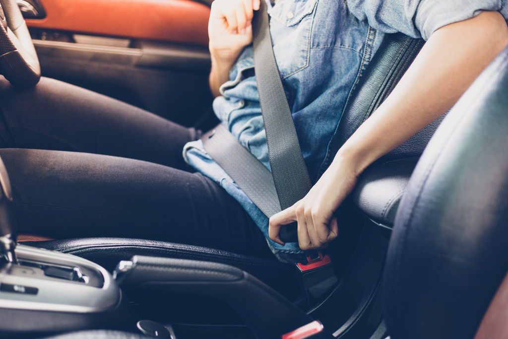

Road traffic accidents are considered as one of the major life-threatening problems in the world that cause significant financial losses and long-term psychological problems. Every year, around 1.35 million people die on the road globally, making this the eighth cause of death globally, and the first leading cause of death in children and young adults aged 5 to 29 <sup>[1]</sup>. From the literature, the human factors contributing to road traffic accidents include speeding, driving under the influence of alcohol, distraction and failure to wear seat belts. Among the most important policy tools that have been used to combat this problem was the passage of mandatory seat belt laws. In a detailed definition, a seat belt is a designed safety harness purposely to secure a person who occupies a motor vehicle against results of harmful movements of the vehicle, which may sometimes be due to a collision or an emergency stop. As part of a safety system in an automobile, a seat belt intended to reduce both deaths and injuries by protecting the user from hitting or knocking hard the interior parts of the vehicle or by avoiding the second impact which occurs between the passengers. The aim of this project is to investigate **the correlation between traffic fatalities and seat belt usage** in the hope that the findings would have substantial implications for policy-making down the road.

This data set contains panel data on the 50 U.S. states and the District of Columbia for the years 1983 to 1997. It contains 765 observations on 13 variables. Although mandatory seat belt laws were adopted in Europe and Australia as early as the 1970s, it was not until December 1984 that such laws were adopted in the United States, New York being the first state to do so. During the observation period, all U.S. jurisdictions gradually adopted seat belt legislation. This pattern of adoption makes it possible to obtain a clear identification of the effects of seat belt usage, controlling for year and state fixed effects.

For this project, only 4 variables including the number of fatalities per million of traffic miles, the seat belt usage rate, the seat belt enforcement and the maximum of 0.08 blood alcohol content will be used. All the data used in this project was retrieved from Stock, J.H. and Watson, M.W. (2007). *Introduction to Econometrics*, 2nd ed. Boston: Addison Wesley and via the website https://rdrr.io/cran/AER/man/USSeatBelts.html

# Data Set Up

```r
library(readr)
library(dplyr)
library(ggplot2)
library(janitor)
library(tidyverse)
library(moderndive)
library(infer)
library(readr)
pj_USseatbelts <- read_csv("https://docs.google.com/spreadsheets/d/e/2PACX-1vSNLViy6eHcfjvfLi2IqJ_a_6k250ZYODGMjifCDVYjqVY_w8njFufWqJ5aZ2WcMks8-VQjxxYlwqwV/pub?gid=443888182&single=true&output=csv")
set.seed(123)
```

Before getting into the main analysis, the data first had to be wrangled. For aesthetic purposes, the whole data set cannot be shown as it would take up most of the project.

This project will primarily be looking at the relationship between traffic fatalities and seat belt usage. Additionally, we will also be looking into the effectiveness of law in increasing the usage and the maximum of blood alcohol content law. As mentioned in the introduction, this project will only make use of only 4 of the 13 variables. The outcome variable is `fatalities`, which is a **numerical** variable representing the number of fatalities per million of traffic miles. Next, we have the **numerical** explanatory variable `seatbelt`, which shows the seat belt usage rate, as self-reported by state population surveyed. One **categorical** explanatory variable we will look at is `enforce`. This variable indicates seat belt law enforcement at three levels: primary enforcement (i.e., allowing the police to stop and fine violators even if they do not engage in other offenses), secondary enforcement (i.e., allowing the police to fine violators only when they are stopped for some other offense) and no enforcement. And the final explanatory variable is also a **categorical** variable `alcohol`, which demonstrates whether or not a maximum of 0.08 blood alcohol content exists in that U.S. state.

```r
glimpse(pj_USseatbelts)
```

```
## Rows: 765
## Columns: 13
## $ X1         <dbl> 1, 2, 3, 4, 5, 6, 7, 8, 9, 10, 11, 12, 13, 14, 15, 16, 1...
## $ state      <chr> "AK", "AK", "AK", "AK", "AK", "AK", "AK", "AK", "AK", "A...
## $ year       <dbl> 1983, 1984, 1985, 1986, 1987, 1988, 1989, 1990, 1991, 19...
## $ miles      <dbl> 3358, 3589, 3840, 4008, 3900, 3841, 3887, 3979, 4021, 38...
## $ fatalities <dbl> 0.04466945, 0.03733630, 0.03307291, 0.02519960, 0.019487...
## $ seatbelt   <dbl> NA, NA, NA, NA, NA, NA, NA, 0.45, 0.66, 0.66, 0.69, 0.69...
## $ speed65    <chr> "no", "no", "no", "no", "no", "no", "no", "no", "no", "y...
## $ speed70    <chr> "no", "no", "no", "no", "no", "no", "no", "no", "no", "n...
## $ drinkage   <chr> "yes", "yes", "yes", "yes", "yes", "yes", "yes", "yes", ...
## $ alcohol    <chr> "no", "no", "no", "no", "no", "no", "no", "no", "no", "n...
## $ income     <dbl> 17973, 18093, 18925, 18466, 18021, 18447, 19970, 21073, ...
## $ age        <dbl> 28.23497, 28.34354, 28.37282, 28.39665, 28.45325, 28.851...
## $ enforce    <chr> "no", "no", "no", "no", "no", "no", "no", "no", "seconda...
```

# Exploratory Data Analysis

## Univariate Analysis

```r
summary(pj_USseatbelts$fatalities)
```

```
##     Min.  1st Qu.   Median     Mean  3rd Qu.     Max.
## 0.008327 0.017341 0.021199 0.021490 0.024774 0.045470
```

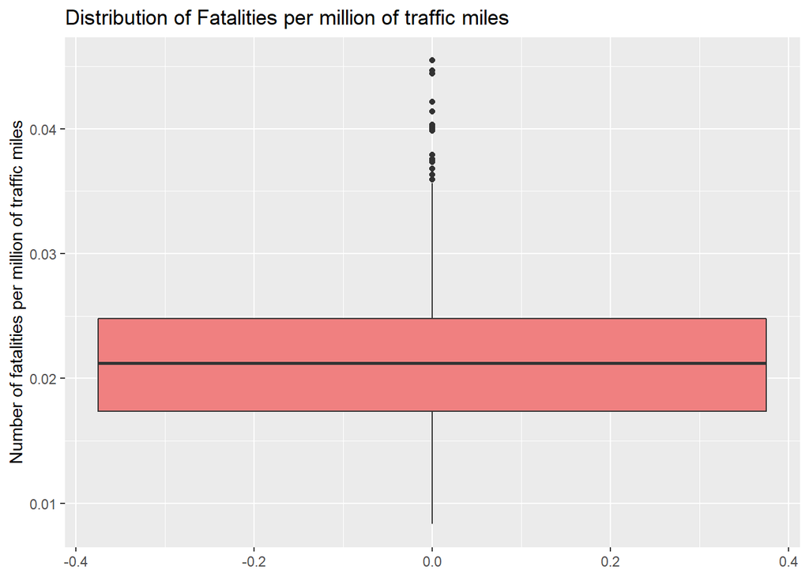

```r
ggplot(data = pj_USseatbelts, aes(y = fatalities)) +
  geom_boxplot(fill = "lightcoral")+
  labs(y = "Number of fatalities per million of traffic miles",
       title = "Distribution of Fatalities per million of traffic miles")
```

The first thing to look at is a simple summary of the numeric variables in this fitted dataset. We will start with a summary of the `fatalities` variable. In each state in the U.S. through the years 1983-1997, the average number of fatalities per million of traffic miles is 0.02. Its max value is 0.05 and min value is 0.008. These numbers overall suggest us a wide variation in the traffic fatalities statistics during the observation period. Also, when looking back at the data, we can see that the max value of fatalities comes from NM (New Mexico), where a combo of no law of a maximum of blood alcohol content and no seat belt enforcement can be seen.

```r
summary(pj_USseatbelts$seatbelt)
```

```
##    Min. 1st Qu.  Median    Mean 3rd Qu.    Max.    NA's
##  0.0600  0.4200  0.5500  0.5289  0.6500  0.8700     209
```

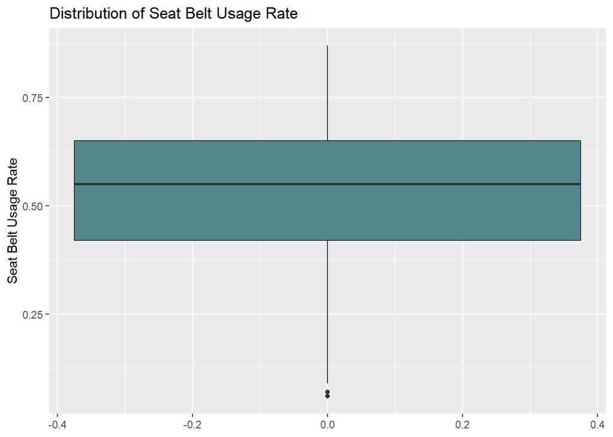

```r
ggplot(data = pj_USseatbelts, aes(y = seatbelt)) +
  geom_boxplot(fill = "cadetblue4")+
  labs(y = "Seat Belt Usage Rate",
       title = "Distribution of Seat Belt Usage Rate")
```

The next variable we are going to be looking at is the second numerical variable `seatbelt`. This variable also yielded some useful data that we can analyze. The average `seatbelt` usage rate is 0.53; its min value is 0.06 and its max value is 0.87. In general, like the previous data about the traffic fatalities, these numbers also suggest us a wide variation in the usage rate across states during the observation period. Given this wide variation, we can also allow the effect of mandatory seat belt legislation to depend on the usage rate that prevailed when the law was passed.

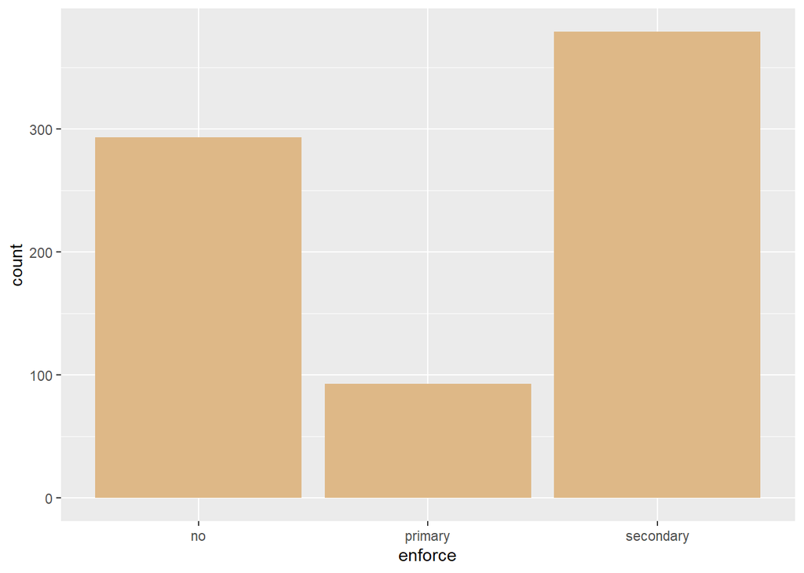

```r
ggplot(data = pj_USseatbelts, mapping = aes (x = enforce)) +
  geom_bar(fill = "burlywood")
```

The third variable we will be looking at is the categorical variable `enforce`. One interesting takeaway from the barplot is that throughout the given period from 1983 to 1997, the number of states having primary seat belt enforcement is much lower than those having secondary enforcement and no enforcement. As discussed in the introduction, during the observation period, all U.S. states except New Hampshire passed mandatory seat belt laws. The variation in the data comes from the fact that states passed such laws at different times and adopted laws with different types of enforcement. Another variation comes from the fact that several states revised their laws, moving from secondary enforcement to primary enforcement. The fact that the adoption of mandatory seat belt laws was quite gradual helps us to identify their effects.

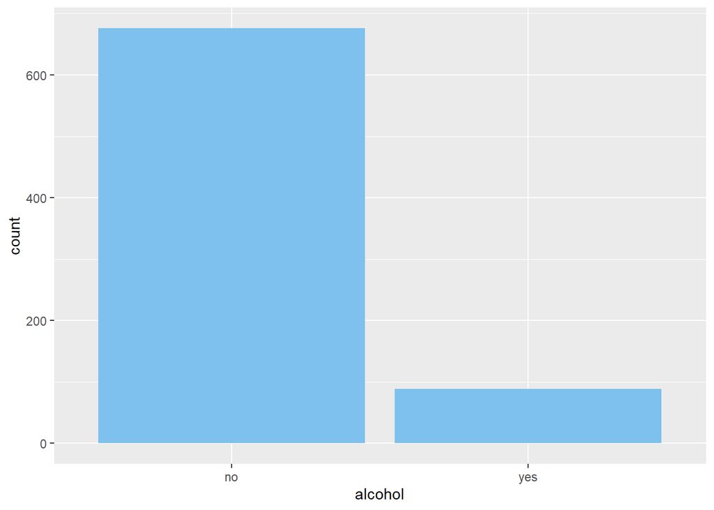

```r
ggplot(data = pj_USseatbelts, mapping = aes (x = alcohol)) +
  geom_bar(fill = "skyblue2")
```

The final variable that we will be taking into consideration is the categorical variable `alcohol`. Overall, the vast majority of the data for this variable belongs to group “no”, meaning that there were very few states having the blood alcohol content limit law during the given period.

## Bivarate Analysis

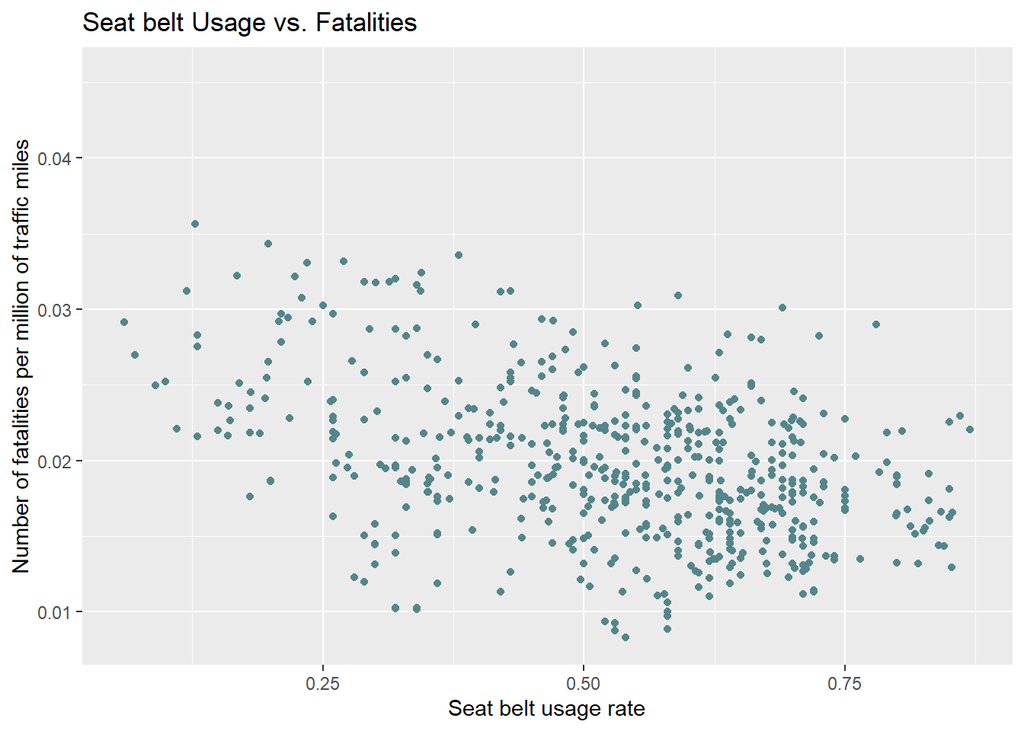

```r
ggplot(data = pj_USseatbelts, aes(y = fatalities, x = seatbelt)) +
  geom_point(color = "cadetblue4") +
  labs(x = "Seat belt usage rate",
       y = "Number of fatalities per million of traffic miles",
       title = "Seat belt Usage vs. Fatalities")
```

We will first do a quick analysis on the relationship between the number of fatalities per million of traffic miles and the seat belt usage rate. To get a better look at the numeric variables, a scatterplot was utilized to visualize the relationship. The pattern on the graph overall shows us a negative correlation between the two variables, meaning that when the seat belt usage rate increase, we witness an decrease in the number of fatalities per million of traffic miles and vice versa.

```r
analysis_summary_1 <- pj_USseatbelts %>%
  group_by(`enforce`) %>%
  summarize(average_seat_belt_usage_rate = mean(`seatbelt`, na.rm = TRUE))
analysis_summary_1
```

| enforce | average_seat_belt_usage_rate |
| --- | --- |
| no | 0.3115367 |
| primary | 0.7021605 |
| secondary | 0.5627668 |

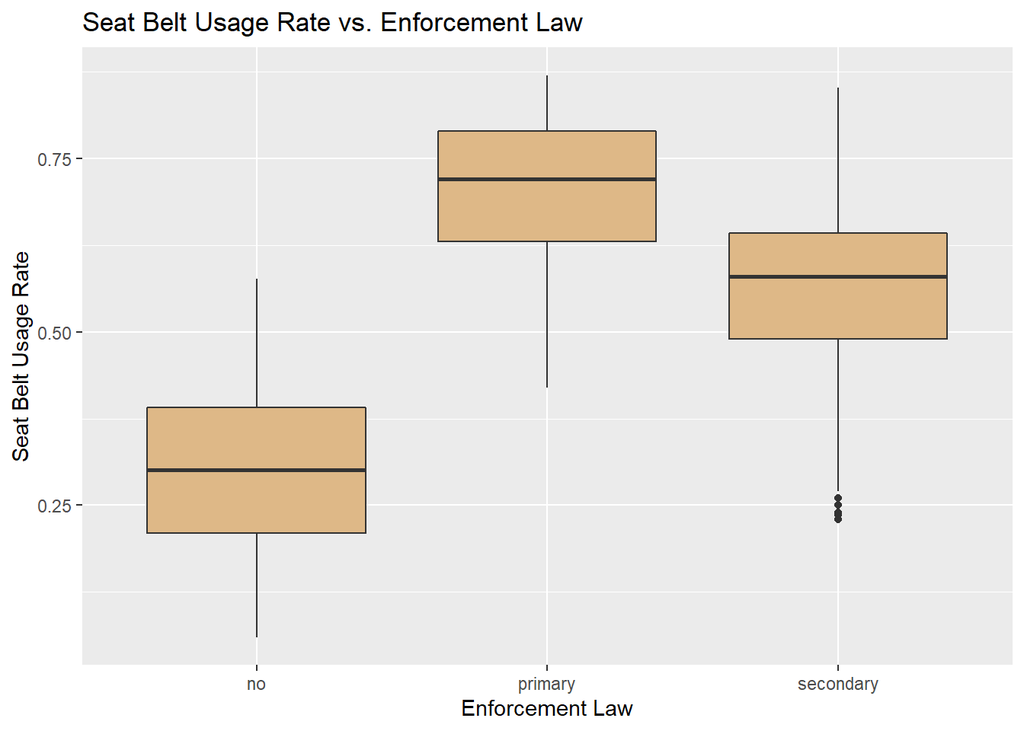

```r
ggplot(data = pj_USseatbelts, aes(y = seatbelt, x = enforce)) +
  geom_boxplot(fill= "burlywood") +
  labs(x = "Enforcement Law",
       y = "Seat Belt Usage Rate",
       title = "Seat Belt Usage Rate vs. Enforcement Law")
```

Presumably, the level of seat belt legislation do not affect fatalities directly but only through their effect on usage, which in turn affects traffic fatalities. By analyzing this way, it allows us for a more direct test of the relationship mentioned in the introduction section, which suggests that the number of traffic fatalities is associated with seat belt usage, not with the existence of mandatory seat belt laws. Therefore, our next step is to do a quick analysis on the effectiveness of such laws in increasing seat belt usage rate throughout the observation period. The boxplot illustrates the correlation between the seat belt usage rate and the level of legislation. As can be seen from the summary table and the graph, the element that seems to be most effective is having primary enforcement. The mean seat belt usage rate, in this case, was 0.7, which is much higher than that of “secondary” level and “no” level. Overall, states with primary seat belt enforcement have on average higher seat belt usage rates.

```r
analysis_summary_2 <- pj_USseatbelts %>%
  group_by(`alcohol`) %>%
  summarize(average_fatalities = mean(`fatalities`, na.rm = TRUE))
analysis_summary_2
```

| alcohol | average_fatalities |
| --- | --- |
| no | 0.0218696 |
| yes | 0.0186028 |

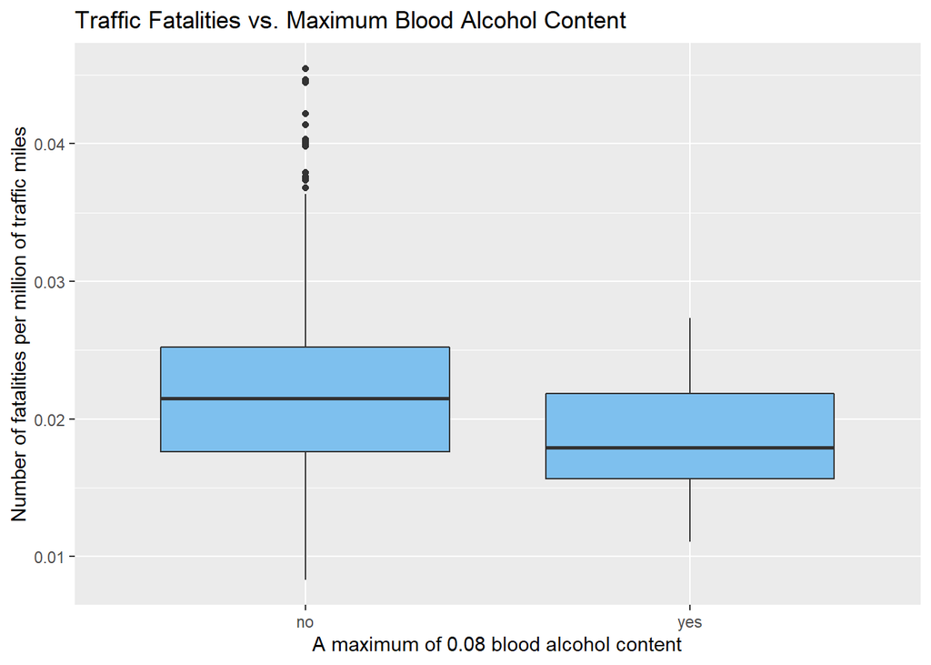

```r
ggplot(data = pj_USseatbelts, aes(y = fatalities, x = alcohol)) +
  geom_boxplot(fill= "skyblue2") +
  labs(x = "A maximum of 0.08 blood alcohol content",
       y = "Number of fatalities per million of traffic miles",
       title = "Traffic Fatalities vs. Maximum Blood Alcohol Content")
```

Finally, we will be looking at one factor that might have an impact on traffic fatalities besides the seat belt usage. That is the existence of a maximum of 0.08 blood alcohol content (BAC) legislation. (For the convenience, during the rest of this project, I will use BAC to refer to blood alcohol content). Like the `enforce` variable, a boxplot can be used to give a better understanding of the `alcohol` variable. One of the key takeaways from the graph is that the greater variability in traffic fatalities is from the “no” group. Probably, this means that the non-existence of the BAC limit law contains more potential risks of causing traffic fatalities. From the table, it is clear that the average number of traffic fatalities in states having the BAC limit law (0.019) was lower than that in states not having the BAC limit law (0.022). It is likely that since people were not afraid of alcohol limitations, they felt free to be in traffic with high blood alcohol concentrations, leading to unconsciousness and careless driving, which in turn cause traffic accidents and fatalities.

# Performing a Simple Regression

As mentioned in the Explanatory Data Analysis section, the level of seat belt legislation presumably do not affect fatalities directly but only through their effect on usage, which in turn affects traffic fatalities. This section is organized as follows. “SLR with Numerical Predictor” discusses how seat belt usage affects fatalities throughout the observation period. “SLR with Categorical Predictor” discusses the effectiveness of the laws in increasing seat belt usage rate.

## SLR with Numerical Predictor

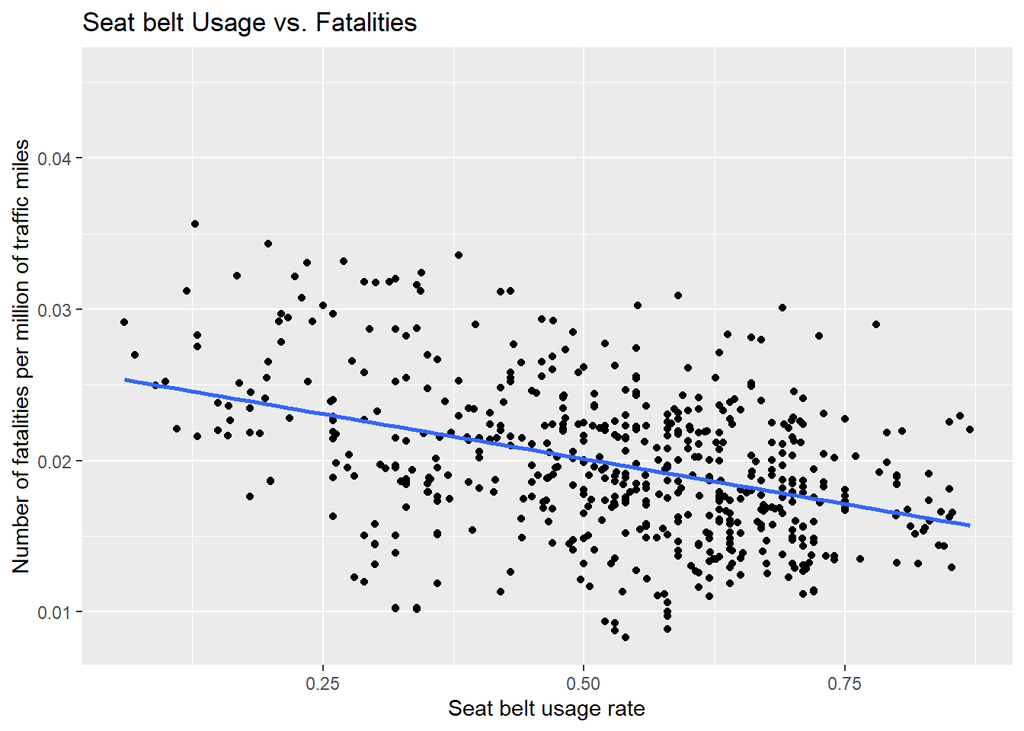

```r
ggplot(data = pj_USseatbelts, aes(y = fatalities, x = seatbelt)) +
  geom_point() +
  geom_smooth(method = "lm", se = FALSE) +
  labs(x = "Seat belt usage rate",
       y = "Number of fatalities per million of traffic miles",
       title = "Seat belt Usage vs. Fatalities")
```

The first regression that we will look at is a simple numerical regression that compares the relationship between the seat belt usage rate and the number of fatalities per million of traffic miles. This plot shows us a scatterplot of this regression, complete with a best-fitting line. One thing we can take away from the graph is the negative slope of the best-fitting line, suggesting that there is a negative relationship between the two variables: as the seat belt usage rate increase, we see an decrease in the number of fatalities per million of traffic miles and vice versa.

```r
SLR_NP_model <- lm(fatalities ~ seatbelt, data = pj_USseatbelts)
get_regression_table(SLR_NP_model)
```

| term | estimate | std_error | statistic | p_value | lower_ci | upper_ci |
| --- | --- | --- | --- | --- | --- | --- |
| intercept | 0.026 | 0.001 | 40.822 | 0 | 0.025 | 0.027 |
| seatbelt | -0.012 | 0.001 | -10.356 | 0 | -0.014 | -0.010 |

In addition, we can build a regression equation from this data to make an appropriate prediction about the number of fatalities per million of traffic miles based on the seat belt usage rate in each state. The equation is as follow:

$$\widehat{y} = 0.026 - 0.012 \times (seatbelt)$$

Using this regression equation, we could solve for an exact prediction of the number of fatalities per million of traffic miles based on the seat belt usage rate in each state. For example, if we want to see how many fatalities per million of traffic miles would be at 0.8 seat belt usage rate, we simply plug in 0.8 into the equation above. The number of fatalities per million of traffic miles then is estimated to be 0.0164

$$\widehat{y} = 0.026 - 0.012 \times 0.8 = 0.0164$$

```r
summary(lm(fatalities ~ seatbelt, data = pj_USseatbelts))
```

```
##
## Call:
## lm(formula = fatalities ~ seatbelt, data = pj_USseatbelts)
##
## Residuals:
##        Min         1Q     Median         3Q        Max
## -0.0120148 -0.0030992 -0.0001796  0.0029431  0.0122668
##
## Coefficients:
##               Estimate Std. Error t value Pr(>|t|)
## (Intercept)  0.0260626  0.0006384   40.82   <2e-16 ***
## seatbelt    -0.0119015  0.0011493  -10.36   <2e-16 ***
## ---
## Signif. codes:  0 '***' 0.001 '**' 0.01 '*' 0.05 '.' 0.1 ' ' 1
##
## Residual standard error: 0.004608 on 554 degrees of freedom
##   (209 observations deleted due to missingness)
## Multiple R-squared:  0.1622, Adjusted R-squared:  0.1607
## F-statistic: 107.2 on 1 and 554 DF,  p-value: < 2.2e-16
```

Next, we will evaluate the goodness of fit of this model. The regression points table shows us residuals towards the data, which were not very large since they mostly fluctuate from $\pm0.001$ to $\pm0.007$ (The table was hidden for aesthetic purposes). Looking at the summary table above, we can see that the r-squared value was 0.1622, indicating that only 16.22% of the data was fit on the line. This overall suggests that the regression model was not really a good fit for the data.

The following data will be used to test the relationship between the two variables. This is where the other coefficients from earlier come into play.

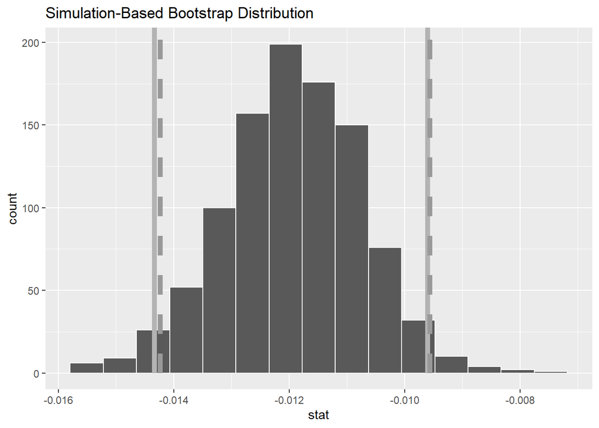

```r
SLR_NP_dist_slope <- pj_USseatbelts %>%
  specify(formula = `fatalities` ~ `seatbelt`) %>%
  generate(reps = 1000, type = 'bootstrap') %>%
  calculate(stat= "slope")

SLR_NP_percentile <- SLR_NP_dist_slope %>%
  get_confidence_interval(type="percentile", level = 0.95)

SLR_NP_observed_slope <- pj_USseatbelts %>%
  specify(`fatalities` ~ `seatbelt`) %>%
  calculate(stat = "slope")

SLR_NP_se_ci <- SLR_NP_dist_slope %>%
  get_ci(level = 0.95, type = "se", point_estimate = SLR_NP_observed_slope)

visualize(SLR_NP_dist_slope) +
  shade_confidence_interval(endpoints = SLR_NP_percentile, fill = NULL,
                            linetype = "solid", color = "grey70") +
  shade_confidence_interval(endpoints = SLR_NP_se_ci, fill = NULL,
                            linetype = "dashed", color = "grey60")
```

```r
null_SLR_NP_dist_slope <- pj_USseatbelts %>%
  specify(`fatalities` ~ `seatbelt`) %>%
  hypothesize(null = "independence") %>%
  generate(reps = 1000, type = "permute") %>%
  calculate(stat = "slope")

null_SLR_NP_dist_slope %>%
  get_p_value(obs_stat =  SLR_NP_observed_slope, direction = "both")
```

| p_value |
| --- |
| 0 |

```r
get_regression_table(SLR_NP_model)
```

| term | estimate | std_error | statistic | p_value | lower_ci | upper_ci |
| --- | --- | --- | --- | --- | --- | --- |
| intercept | 0.026 | 0.001 | 40.822 | 0 | 0.025 | 0.027 |
| seatbelt | -0.012 | 0.001 | -10.356 | 0 | -0.014 | -0.010 |

Now we will get back to the remainder columns. The p-value shows us how extreme the test statistic is of -0.012 compared to the null distribution. In this case, we received a p-value of 0, which is a strong indicator of statistical significance. The confidence interval values correspond to a 95% confidence interval for the `seatbelt` slope. Furthermore, because 0 does not fall within the confidence intervals, we can be certain that the relationship between the two variables is statistically significant.

**Testing a hypothesis:**

Null hypothesis: There is no significant relationship between the number of fatalities per million of traffic miles and the seat belt usage rate.

Alternative hypothesis: There is a significant relationship between the number of fatalities per million of traffic miles and the seat belt usage rate.

**Results:**

As seen in the visual, 0 does not fall within the confidence intervals and the observed p-value is small for a conservative test of 0.05. Given this, we would reject the Null hypothesis and conclude that there is a significant relationship between the number of fatalities per million of traffic miles and the seat belt usage rate.

## SLR with Categorical Predictor

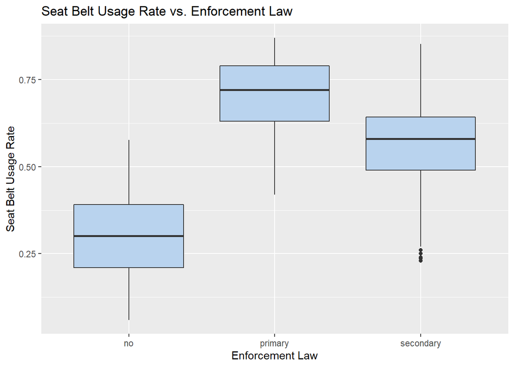

```r
ggplot(data = pj_USseatbelts, aes(y = seatbelt, x = enforce)) +
  geom_boxplot(fill= "slategray2") +
  labs(x = "Enforcement Law",
       y = "Seat Belt Usage Rate",
       title = "Seat Belt Usage Rate vs. Enforcement Law")
```

The next step is to analyze which elements of seat belt legislation make it effective in increasing usage rate. We will look at a categorical regression that shows the relationship between the seat belt enforcement law and seat belt usage rate. The elements that we will consider include having primary enforcement (i.e., allowing the police to stop and fine violators even if they do not engage in other offenses), secondary enforcement (i.e., allowing the police to fine violators only when they are stopped for some other offense) and no enforcement. The boxplot above shows us the comparison between these three different levels. One important observation is that the seat belt usage rates when having either primary enforcement or secondary enforcement were substantially higher than the seat belt usage rates when having no enforcement. Also, the element that seems to be most effective in this respect is having primary enforcement.

```r
SLR_CP_model <- lm(`seatbelt` ~ `enforce`, data = pj_USseatbelts)
get_regression_table(SLR_CP_model)
```

| term | estimate | std_error | statistic | p_value | lower_ci | upper_ci |
| --- | --- | --- | --- | --- | --- | --- |
| intercept | 0.312 | 0.011 | 29.176 | 0 | 0.291 | 0.333 |
| enforceprimary | 0.391 | 0.017 | 23.223 | 0 | 0.358 | 0.424 |
| enforcesecondary | 0.251 | 0.012 | 20.340 | 0 | 0.227 | 0.275 |

Like last time, there is a fair bit of information that can be gathered from the coefficients. The `intercept` means that the average seat belt usage rate in states with no seat belt enforcement is 0.312. `enforceprimary` corresponds to states having primary seat belt enforcement and the seat belt usage rate in this case is estimated to be 0.312 + 0.391 = 0.703. Similarly, `enforcesecondary` corresponds to states having secondary seat belt enforcement. The seat belt usage rate in this case is predicted to be 0.312 + 0.251 = 0.563

The standard error again shows us the sampling variability of the data, in this case 0.011 with an additional 0.017 or 0.012 percentage depending on the level of the enforcement law. Like last time, we will get back to the coefficients later.

This time, the equation for a categorical regression equation will be used to predict the seat belt usage rate based on the level of the seat belt enforcement law (“no”, “primary” and “secondary”). The equation for this regression is as follows:

```r
pj_USseatbelts %>%
  group_by(`enforce`) %>%
  summarize(mean_seatbelt = mean(`seatbelt`, na.rm = T))
```

| enforce | mean_seatbelt |
| --- | --- |
| no | 0.3115367 |
| primary | 0.7021605 |
| secondary | 0.5627668 |

$$\widehat{y} = 0.312 + 0.391 \times 1_{\mbox{primary}}(x) + 0.251 \times 1_{\mbox{secondary}}(x)$$
Using this equation, we could predict the seat belt usage rate in each level of enforcement law. Say we are considering there is no seat belt law enforcement, we would plug in 0 to the others. The estimated number of seat belt usage rate in this case would be 0.312

$$\widehat{y} = 0.312 + 0.391 \times 0 + 0.251 \times 0 = 0.312$$
Similarly, suppose we want to calculate the seat belt usage rate when the seat belt enforcement is primary, the equation is as follows:

$$\widehat{y} = 0.312 + 0.391 \times 1 + 0.251 \times 0 = 0.703$$
Finally, suppose we want to calculate the seat belt usage rate when the seat belt enforcement is secondary, the equation is as follows:

$$\widehat{y} = 0.312 + 0.391 \times 0 + 0.251 \times 1 = 0.563$$

Basically, these results are similar to the results from the table.

```r
summary(lm(seatbelt ~ enforce, data = pj_USseatbelts))
```

```
##
## Call:
## lm(formula = seatbelt ~ enforce, data = pj_USseatbelts)
##
## Residuals:
##      Min       1Q   Median       3Q      Max
## -0.33277 -0.07277  0.00846  0.07963  0.28923
##
## Coefficients:
##                  Estimate Std. Error t value Pr(>|t|)
## (Intercept)       0.31154    0.01068   29.18   <2e-16 ***
## enforceprimary    0.39062    0.01682   23.22   <2e-16 ***
## enforcesecondary  0.25123    0.01235   20.34   <2e-16 ***
## ---
## Signif. codes:  0 '***' 0.001 '**' 0.01 '*' 0.05 '.' 0.1 ' ' 1
##
## Residual standard error: 0.117 on 553 degrees of freedom
##   (209 observations deleted due to missingness)
## Multiple R-squared:  0.5293, Adjusted R-squared:  0.5276
## F-statistic: 310.9 on 2 and 553 DF,  p-value: < 2.2e-16
```

Similar to the numerical regression, it is important to look at the fit of the data. Although the data might not be visually represented via a line of best fit, we can still test the goodness of our regression using an r-squared value. In this case, the r-squared value was 0.5293, indicating that 52.93% of the data was fit on the line. This overall suggests that the regression model was fairly a good fit for the data.

Like last time, the data will also be used to test the relationship between the two variables.

```r
SLR_CP_dist_slope <- pj_USseatbelts %>%
  specify(formula = `seatbelt` ~ `enforce`) %>%
  generate(reps = 1000, type = 'bootstrap') %>%
  calculate(stat="slope")

SLR_CP_observed_slope <- pj_USseatbelts %>%
  specify(`seatbelt` ~ `enforce`) %>%
  calculate(stat = "slope")

null_SLR_CP_dist_slope <- pj_USseatbelts %>%
  specify(`seatbelt` ~ `enforce`) %>%
  hypothesize(null = "independence") %>%
  generate(reps = 1000, type = "permute") %>%
  calculate(stat = "slope")

null_SLR_CP_dist_slope %>%
  get_p_value(obs_stat =  SLR_CP_observed_slope, direction = "both")
```

| p_value |
| --- |
| 0 |

```r
SLR_CP_model <- lm(`seatbelt` ~ `enforce`, data = pj_USseatbelts)
get_regression_table(SLR_CP_model)
```

| term | estimate | std_error | statistic | p_value | lower_ci | upper_ci |
| --- | --- | --- | --- | --- | --- | --- |
| intercept | 0.312 | 0.011 | 29.176 | 0 | 0.291 | 0.333 |
| enforceprimary | 0.391 | 0.017 | 23.223 | 0 | 0.358 | 0.424 |
| enforcesecondary | 0.251 | 0.012 | 20.340 | 0 | 0.227 | 0.275 |

The p-value shows us the probability of obtaining results at least as extreme as the observed results of a statistical hypothesis test, assuming that the null hypothesis is correct. In this case, we received a small p-value of 0, which is less than 0.05. Additionally, none of the confidence intervals contain 0, indicating that the relationship between the two variables is statistically significant.

**Testing a hypothesis:**

Null hypothesis: There is no significant relationship between the seat belt usage rate and the level of seat belt enforcement.

Alternative hypothesis: There is a significant relationship between the seat belt usage rate and the level of seat belt enforcement.

**Results:**

As can be seen, 0 does not fall within the confidence intervals and the observed p-value is small for a conservative test of 0.05. Given this, we would reject the Null hypothesis and conclude that there is a significant relationship between the seat belt usage rate and the level of seat belt enforcement.

# Performing a Multiple Regression

## Parallel Slopes Model

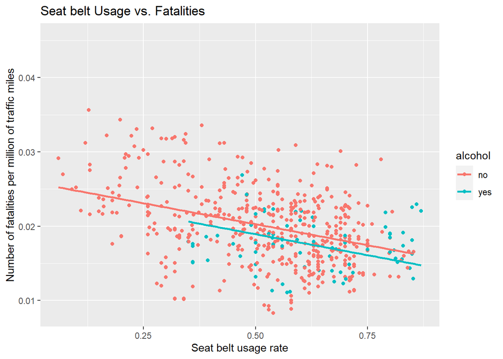

```r
ggplot(data = pj_USseatbelts, aes(y = fatalities, x = seatbelt, color = alcohol)) +
  geom_point() +
  labs(x = "Seat belt usage rate",
       y = "Number of fatalities per million of traffic miles",
       title = "Seat belt Usage vs. Fatalities") +
    geom_parallel_slopes(se = FALSE)
```

```r
parallel_slopes_model_MP <- lm(`fatalities` ~ `seatbelt` + `alcohol`, data = pj_USseatbelts)
get_regression_table(parallel_slopes_model_MP)
```

| term | estimate | std_error | statistic | p_value | lower_ci | upper_ci |
| --- | --- | --- | --- | --- | --- | --- |
| intercept | 0.026 | 0.001 | 40.552 | 0.000 | 0.025 | 0.027 |
| seatbelt | -0.011 | 0.001 | -9.594 | 0.000 | -0.014 | -0.009 |
| alcoholyes | -0.001 | 0.001 | -2.302 | 0.022 | -0.002 | 0.000 |

```r
get_regression_summaries(parallel_slopes_model_MP)
```

| r_squared | adj_r_squared | mse | rmse | sigma | statistic | p_value | df | nobs |
| --- | --- | --- | --- | --- | --- | --- | --- | --- |
| 0.17 | 0.167 | 2.1e-05 | 0.0045776 | 0.005 | 56.684 | 0 | 2 | 556 |

The standard error shows us the sampling variability of the data, in this case, 0.001 with an additional 0.001 percentage in the slope variable `seatbelt`. The p-value, like the past two regressions, shows us how extreme the test statistic is of -0.011 compared to the null distribution. In this case, we received a small p-value that was less than 0.05, meaning that it is a strong indicator of statistical significance. The confidence interval values correspond to a 95% confidence interval for the `seatbelt` slope. Additionally, since the confidence interval is a small interval that does not contain 0, this still suggests a statistically significant relationship between two variables.

The bottom row also brings about valuable information. `alcoholyes` means that in states having the BAC limit law, when the seat belt usage rate is 0, the average number of fatalities per million of traffic miles is 0.026 - 0.001 = 0.025. We also received a small p-value of 0.022, which is still a smaller number compared to 0.05, suggesting a strong indicator of statistical significance.

## Interaction Model

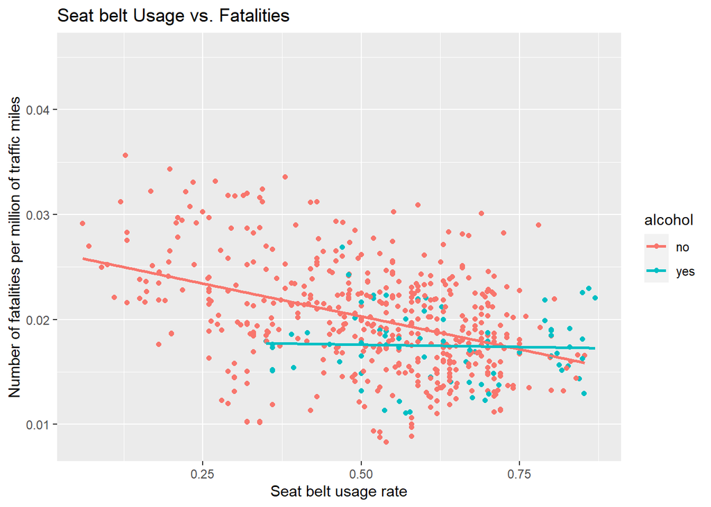

```r
ggplot(data = pj_USseatbelts, aes(y = fatalities, x = seatbelt, color = alcohol)) +
  geom_point() +
  labs(x = "Seat belt usage rate",
       y = "Number of fatalities per million of traffic miles",
       title = "Seat belt Usage vs. Fatalities") +
  geom_smooth(method = "lm", se = FALSE)
```

```r
interaction_model_MP <- lm(`fatalities` ~ `seatbelt` * `alcohol`, data = pj_USseatbelts)
get_regression_table(interaction_model_MP)
```

| term | estimate | std_error | statistic | p_value | lower_ci | upper_ci |
| --- | --- | --- | --- | --- | --- | --- |
| intercept | 0.027 | 0.001 | 39.791 | 0.000 | 0.025 | 0.028 |
| seatbelt | -0.013 | 0.001 | -10.155 | 0.000 | -0.015 | -0.010 |
| alcoholyes | -0.009 | 0.002 | -3.584 | 0.000 | -0.013 | -0.004 |
| seatbelt:alcoholyes | 0.012 | 0.004 | 3.112 | 0.002 | 0.004 | 0.019 |

```r
get_regression_summaries(interaction_model_MP)
```

| r_squared | adj_r_squared | mse | rmse | sigma | statistic | p_value | df | nobs |
| --- | --- | --- | --- | --- | --- | --- | --- | --- |
| 0.184 | 0.18 | 2.06e-05 | 0.004538 | 0.005 | 41.61 | 0 | 3 | 556 |

By getting a regression summary on the data, we see that the model fits 18.4% of the data as opposed to 17% seen with the parallel slopes model. Though these two numbers are not very large enough for us to say either of them was a very good fit for the data, the interaction model could still be considered as the better one.

**Testing a hypothesis:**

1. Null hypothesis: There is no significant relationship between the number of fatalities per million of traffic miles and the seat belt usage rate and the BAC limit law.
2. Alternative hypothesis: There is a significant relationship between the number of fatalities per million of traffic miles and the seat belt usage rate and the BAC limit law.

**Results:**

Using the data earlier in this section, we can test the hypothesis above. Since 0 does not fall within the confidence intervals and the p-values are small for a conservative test of 0.05, we would reject the Null hypothesis, and conclude that there is a significant relationship between the number of fatalities per million of traffic miles and the seat belt usage rate and the BAC limit law.

# Taking a T-Test

Another way to test a hypothesis is by using a t-test. For this test, we are going to be looking at the `fatalities` response as opposed to the `alcohol`. We will test to see if the BAC law is still linked to the number of fatalities per million of traffic miles in each U.S. state or the result would be different from the regression.

**Testing a hypothesis:**

Null hypothesis: There is no significant relationship between the number of fatalities per million of traffic miles and the BAC limit law.

Alternative hypothesis: There is a significant relationship between the number of fatalities per million of traffic miles and the BAC limit law.

```r
t.test(pj_USseatbelts$`fatalities` ~ pj_USseatbelts$`alcohol`)
```

```
##
##  Welch Two Sample t-test
##
## data:  pj_USseatbelts$fatalities by pj_USseatbelts$alcohol
## t = 6.5169, df = 147.91, p-value = 1.06e-09
## alternative hypothesis: true difference in means is not equal to 0
## 95 percent confidence interval:
##  0.002276185 0.004257380
## sample estimates:
##  mean in group no mean in group yes
##        0.02186957        0.01860279
```

**Results:**

The mean of group No (x¯ = 0.02186957) was greater than the mean of group Yes (x¯ = 0.01860279). This difference was statistically significant at α=0.05, (p-value = 1.06e-09 < 0.05). In addition, 0 did not fall within the 95% confidence interval. Given this, I would reject the Null hypothesis and conclude that there is a significant relationship between the number of fatalities per million of traffic miles and the BAC limit law. Overall, we received the same result as the one from the regression.

# Conclusion

Generally, we see that the advancement in technology and the improved economic standards has in some way increased the number of automobiles on the roads. Along with that, traffic accidents have been a major source of fatalities and serious injuries. The seat belt is an effective safety tool that not only saves lives, but also significantly reduces the severity of the injury that a vehicle occupant may have sustained if they were not wearing the device. Perhaps a person with more coding experience would be able to draw more useful conclusions upon this data set, but overall, from my findings, public enlightenment is obviously needed to increase the awareness and compliance of use of seat belt.

Finally, it was interesting to work on this project, and the hope would be that these findings would be of interest to federal and state officials who have been investing a great deal of effort in trying to reduce traffic fatalities, as well as increase seat belt use.

# References

[1] W.H.O. (2018). *Global status report on road safety 2018*: World Health Organization.